# Risk Factor Analysis

## Outcome Variable

**Outcome Variable:** stunted

## Predictor Variables

**Intervention Variable:** mhtcm

**Adjustment Set:**

- arm
- W_mage
- meducyrs
- feducyrs
- hhwealth_quart
- single
- delta_W_mage
- delta_meducyrs
- delta_feducyrs
- delta_hhwealth_quart
- delta_single

## Stratifying Variables

The analysis was stratified on these variable(s):

- agecat
- studyid
- country

## Data Summary

| agecat | studyid | country | mhtcm | stunted | n_cell | n |
| --- | --- | --- | --- | --- | --- | --- |
| Birth | ki0047075b-MAL-ED | BANGLADESH | >=155 cm | 0 | 19 | 222 |
| Birth | ki0047075b-MAL-ED | BANGLADESH | >=155 cm | 1 | 3 | 222 |
| Birth | ki0047075b-MAL-ED | BANGLADESH | <151 cm | 0 | 115 | 222 |
| Birth | ki0047075b-MAL-ED | BANGLADESH | <151 cm | 1 | 30 | 222 |
| Birth | ki0047075b-MAL-ED | BANGLADESH | [151-155) cm | 0 | 48 | 222 |
| Birth | ki0047075b-MAL-ED | BANGLADESH | [151-155) cm | 1 | 7 | 222 |
| Birth | ki0047075b-MAL-ED | BRAZIL | >=155 cm | 0 | 31 | 64 |
| Birth | ki0047075b-MAL-ED | BRAZIL | >=155 cm | 1 | 1 | 64 |
| Birth | ki0047075b-MAL-ED | BRAZIL | <151 cm | 0 | 14 | 64 |
| Birth | ki0047075b-MAL-ED | BRAZIL | <151 cm | 1 | 6 | 64 |
| Birth | ki0047075b-MAL-ED | BRAZIL | [151-155) cm | 0 | 10 | 64 |
| Birth | ki0047075b-MAL-ED | BRAZIL | [151-155) cm | 1 | 2 | 64 |
| Birth | ki0047075b-MAL-ED | INDIA | >=155 cm | 0 | 10 | 43 |
| Birth | ki0047075b-MAL-ED | INDIA | >=155 cm | 1 | 2 | 43 |
| Birth | ki0047075b-MAL-ED | INDIA | <151 cm | 0 | 15 | 43 |
| Birth | ki0047075b-MAL-ED | INDIA | <151 cm | 1 | 5 | 43 |
| Birth | ki0047075b-MAL-ED | INDIA | [151-155) cm | 0 | 9 | 43 |
| Birth | ki0047075b-MAL-ED | INDIA | [151-155) cm | 1 | 2 | 43 |
| Birth | ki0047075b-MAL-ED | NEPAL | >=155 cm | 0 | 6 | 27 |
| Birth | ki0047075b-MAL-ED | NEPAL | >=155 cm | 1 | 0 | 27 |
| Birth | ki0047075b-MAL-ED | NEPAL | <151 cm | 0 | 12 | 27 |
| Birth | ki0047075b-MAL-ED | NEPAL | <151 cm | 1 | 1 | 27 |
| Birth | ki0047075b-MAL-ED | NEPAL | [151-155) cm | 0 | 7 | 27 |
| Birth | ki0047075b-MAL-ED | NEPAL | [151-155) cm | 1 | 1 | 27 |
| Birth | ki0047075b-MAL-ED | PERU | >=155 cm | 0 | 45 | 226 |
| Birth | ki0047075b-MAL-ED | PERU | >=155 cm | 1 | 3 | 226 |
| Birth | ki0047075b-MAL-ED | PERU | <151 cm | 0 | 112 | 226 |
| Birth | ki0047075b-MAL-ED | PERU | <151 cm | 1 | 19 | 226 |
| Birth | ki0047075b-MAL-ED | PERU | [151-155) cm | 0 | 43 | 226 |
| Birth | ki0047075b-MAL-ED | PERU | [151-155) cm | 1 | 4 | 226 |

[output cut: 324 more lines]

The following strata were considered:

- agecat: 24 months, studyid: ki0047075b-MAL-ED, country: BANGLADESH
- agecat: 24 months, studyid: ki0047075b-MAL-ED, country: BRAZIL
- agecat: 24 months, studyid: ki0047075b-MAL-ED, country: INDIA
- agecat: 24 months, studyid: ki0047075b-MAL-ED, country: NEPAL
- agecat: 24 months, studyid: ki0047075b-MAL-ED, country: PERU
- agecat: 24 months, studyid: ki0047075b-MAL-ED, country: SOUTH AFRICA
- agecat: 24 months, studyid: ki0047075b-MAL-ED, country: TANZANIA, UNITED REPUBLIC OF
- agecat: 24 months, studyid: ki1017093-NIH-Birth, country: BANGLADESH
- agecat: 24 months, studyid: ki1017093b-PROVIDE, country: BANGLADESH
- agecat: 24 months, studyid: ki1017093c-NIH-Crypto, country: BANGLADESH
- agecat: 24 months, studyid: ki1066203-TanzaniaChild2, country: TANZANIA, UNITED REPUBLIC OF
- agecat: 24 months, studyid: ki1101329-Keneba, country: GAMBIA
- agecat: 24 months, studyid: ki1119695-PROBIT, country: BELARUS
- agecat: 24 months, studyid: ki1126311-ZVITAMBO, country: ZIMBABWE
- agecat: 24 months, studyid: ki1135781-COHORTS, country: GUATEMALA
- agecat: 24 months, studyid: ki1135781-COHORTS, country: INDIA
- agecat: 24 months, studyid: ki1135781-COHORTS, country: PHILIPPINES
- agecat: 24 months, studyid: ki1148112-LCNI-5, country: MALAWI
- agecat: 24 months, studyid: kiGH5241-JiVitA-3, country: BANGLADESH
- agecat: 6 months, studyid: ki0047075b-MAL-ED, country: BANGLADESH
- agecat: 6 months, studyid: ki0047075b-MAL-ED, country: BRAZIL
- agecat: 6 months, studyid: ki0047075b-MAL-ED, country: INDIA
- agecat: 6 months, studyid: ki0047075b-MAL-ED, country: NEPAL
- agecat: 6 months, studyid: ki0047075b-MAL-ED, country: PERU
- agecat: 6 months, studyid: ki0047075b-MAL-ED, country: SOUTH AFRICA
- agecat: 6 months, studyid: ki0047075b-MAL-ED, country: TANZANIA, UNITED REPUBLIC OF
- agecat: 6 months, studyid: ki1000304b-SAS-CompFeed, country: INDIA
- agecat: 6 months, studyid: ki1000304b-SAS-FoodSuppl, country: INDIA
- agecat: 6 months, studyid: ki1017093-NIH-Birth, country: BANGLADESH
- agecat: 6 months, studyid: ki1017093b-PROVIDE, country: BANGLADESH
- agecat: 6 months, studyid: ki1017093c-NIH-Crypto, country: BANGLADESH
- agecat: 6 months, studyid: ki1066203-TanzaniaChild2, country: TANZANIA, UNITED REPUBLIC OF
- agecat: 6 months, studyid: ki1101329-Keneba, country: GAMBIA
- agecat: 6 months, studyid: ki1112895-Guatemala BSC, country: GUATEMALA
- agecat: 6 months, studyid: ki1119695-PROBIT, country: BELARUS
- agecat: 6 months, studyid: ki1126311-ZVITAMBO, country: ZIMBABWE
- agecat: 6 months, studyid: ki1135781-COHORTS, country: GUATEMALA
- agecat: 6 months, studyid: ki1135781-COHORTS, country: INDIA
- agecat: 6 months, studyid: ki1135781-COHORTS, country: PHILIPPINES
- agecat: 6 months, studyid: ki1148112-LCNI-5, country: MALAWI
- agecat: 6 months, studyid: kiGH5241-JiVitA-3, country: BANGLADESH
- agecat: Birth, studyid: ki0047075b-MAL-ED, country: BANGLADESH
- agecat: Birth, studyid: ki0047075b-MAL-ED, country: BRAZIL
- agecat: Birth, studyid: ki0047075b-MAL-ED, country: INDIA
- agecat: Birth, studyid: ki0047075b-MAL-ED, country: NEPAL
- agecat: Birth, studyid: ki0047075b-MAL-ED, country: PERU
- agecat: Birth, studyid: ki0047075b-MAL-ED, country: SOUTH AFRICA
- agecat: Birth, studyid: ki0047075b-MAL-ED, country: TANZANIA, UNITED REPUBLIC OF
- agecat: Birth, studyid: ki1000304b-SAS-CompFeed, country: INDIA
- agecat: Birth, studyid: ki1017093-NIH-Birth, country: BANGLADESH
- agecat: Birth, studyid: ki1017093b-PROVIDE, country: BANGLADESH
- agecat: Birth, studyid: ki1017093c-NIH-Crypto, country: BANGLADESH
- agecat: Birth, studyid: ki1101329-Keneba, country: GAMBIA
- agecat: Birth, studyid: ki1119695-PROBIT, country: BELARUS
- agecat: Birth, studyid: ki1126311-ZVITAMBO, country: ZIMBABWE
- agecat: Birth, studyid: ki1135781-COHORTS, country: GUATEMALA
- agecat: Birth, studyid: ki1135781-COHORTS, country: INDIA
- agecat: Birth, studyid: ki1135781-COHORTS, country: PHILIPPINES
- agecat: Birth, studyid: kiGH5241-JiVitA-3, country: BANGLADESH

### Dropped Strata

Some strata were dropped due to rare outcomes:

- agecat: Birth, studyid: ki0047075b-MAL-ED, country: BANGLADESH
- agecat: Birth, studyid: ki0047075b-MAL-ED, country: BRAZIL
- agecat: Birth, studyid: ki0047075b-MAL-ED, country: INDIA
- agecat: Birth, studyid: ki0047075b-MAL-ED, country: NEPAL
- agecat: Birth, studyid: ki0047075b-MAL-ED, country: PERU
- agecat: Birth, studyid: ki0047075b-MAL-ED, country: SOUTH AFRICA
- agecat: Birth, studyid: ki1119695-PROBIT, country: BELARUS
- agecat: 6 months, studyid: ki0047075b-MAL-ED, country: BANGLADESH
- agecat: 6 months, studyid: ki0047075b-MAL-ED, country: BRAZIL
- agecat: 6 months, studyid: ki0047075b-MAL-ED, country: NEPAL
- agecat: 24 months, studyid: ki0047075b-MAL-ED, country: BANGLADESH
- agecat: 24 months, studyid: ki0047075b-MAL-ED, country: BRAZIL
- agecat: 24 months, studyid: ki0047075b-MAL-ED, country: NEPAL
- agecat: 24 months, studyid: ki0047075b-MAL-ED, country: TANZANIA, UNITED REPUBLIC OF
- agecat: 24 months, studyid: ki1066203-TanzaniaChild2, country: TANZANIA, UNITED REPUBLIC OF

## Methods Detail

We’re interested in the causal parameters $E[Y_a]$ for all values of $a \in \mathcal{A}$. These parameters represent the mean outcome if, possibly contrary to fact, we intervened to set all units to have $A=a$. Under the randomization and positivity assumptions, these are identified by the statistical parameters $\psi_a=E_W[E_{Y|A,W}(Y|A=a,W)]$. In addition, we’re interested in the mean of $Y$, $E[Y]$ under no intervention (the observed mean). We will estimate these parameters by using SuperLearner to fit the relevant likelihood factors – $E_{Y|A,W}(Y|A=a,W)$ and $p(A=a|W)$, and then updating our likelihood fit using a joint TMLE.

For unadjusted analyses ($W=\{\}$), initial likelihoods were estimated using Lrnr_glm to estimate the simple $E(Y|A)$ and Lrnr_mean to estimate $p(A)$. For adjusted analyses, a small library containing Lrnr_glmnet, Lrnr_xgboost, and Lrnr_mean was used.

Having estimated these parameters, we will then use the delta method to estimate relative risks and attributable risks relative to a prespecified baseline level of $A$.

# Results Detail

## Results Plots

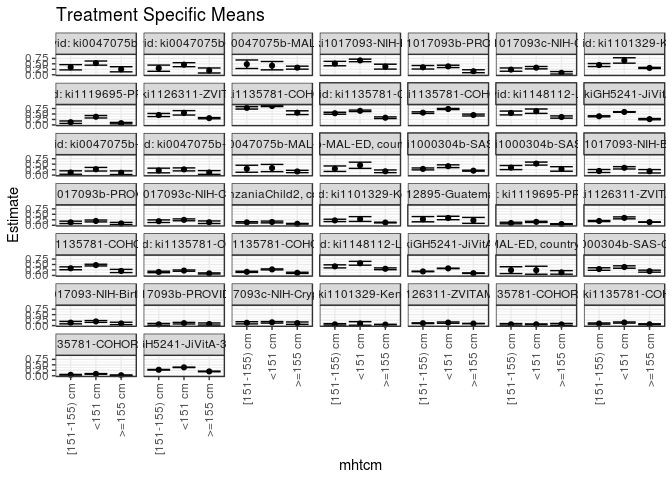

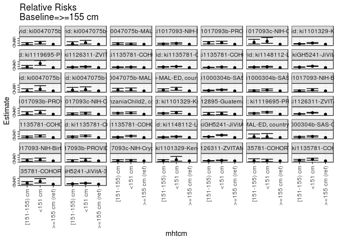

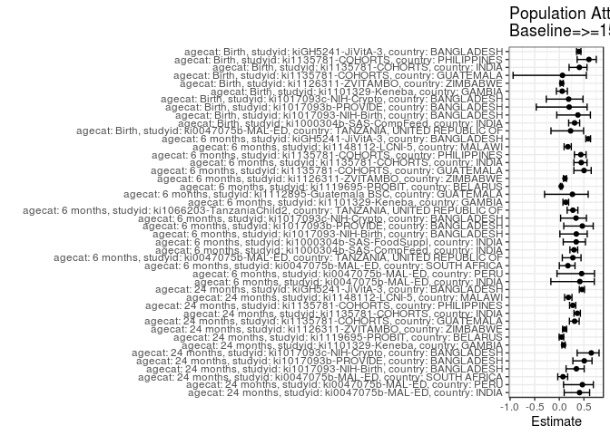

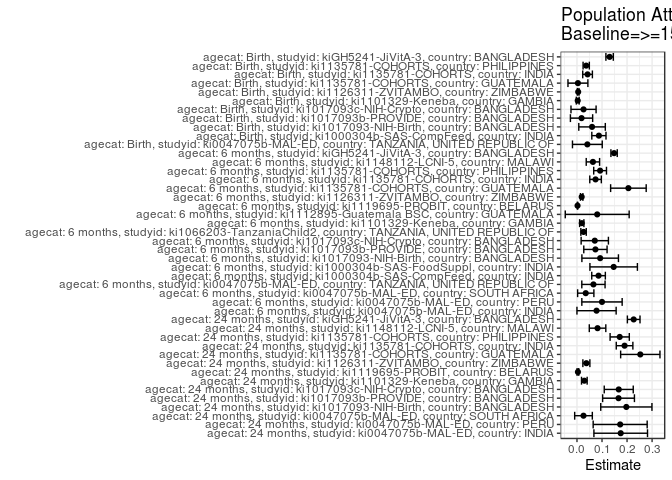

## Results Table

### Parameter: TSM

| agecat | studyid | country | intervention_level | baseline_level | estimate | ci_lower | ci_upper |
| --- | --- | --- | --- | --- | --- | --- | --- |
| Birth | ki0047075b-MAL-ED | TANZANIA, UNITED REPUBLIC OF | >=155 cm | NA | 0.1388889 | 0.0586782 | 0.2190996 |
| Birth | ki0047075b-MAL-ED | TANZANIA, UNITED REPUBLIC OF | <151 cm | NA | 0.2380952 | 0.0551794 | 0.4210111 |
| Birth | ki0047075b-MAL-ED | TANZANIA, UNITED REPUBLIC OF | [151-155) cm | NA | 0.2413793 | 0.0849930 | 0.3977656 |
| Birth | ki1000304b-SAS-CompFeed | INDIA | >=155 cm | NA | 0.1943834 | 0.1485391 | 0.2402276 |
| Birth | ki1000304b-SAS-CompFeed | INDIA | <151 cm | NA | 0.3845668 | 0.3301427 | 0.4389908 |
| Birth | ki1000304b-SAS-CompFeed | INDIA | [151-155) cm | NA | 0.2915577 | 0.2341995 | 0.3489158 |
| Birth | ki1017093-NIH-Birth | BANGLADESH | >=155 cm | NA | 0.0993552 | 0.0438575 | 0.1548528 |
| Birth | ki1017093-NIH-Birth | BANGLADESH | <151 cm | NA | 0.1888723 | 0.1481116 | 0.2296331 |
| Birth | ki1017093-NIH-Birth | BANGLADESH | [151-155) cm | NA | 0.1357133 | 0.0790820 | 0.1923446 |
| Birth | ki1017093b-PROVIDE | BANGLADESH | >=155 cm | NA | 0.0727273 | 0.0241510 | 0.1213036 |
| Birth | ki1017093b-PROVIDE | BANGLADESH | <151 cm | NA | 0.1118881 | 0.0753193 | 0.1484570 |
| Birth | ki1017093b-PROVIDE | BANGLADESH | [151-155) cm | NA | 0.0578512 | 0.0162130 | 0.0994894 |
| Birth | ki1017093c-NIH-Crypto | BANGLADESH | >=155 cm | NA | 0.1123734 | 0.0581183 | 0.1666285 |
| Birth | ki1017093c-NIH-Crypto | BANGLADESH | <151 cm | NA | 0.1505886 | 0.1161775 | 0.1849997 |
| Birth | ki1017093c-NIH-Crypto | BANGLADESH | [151-155) cm | NA | 0.1274786 | 0.0778574 | 0.1770998 |
| Birth | ki1101329-Keneba | GAMBIA | >=155 cm | NA | 0.0480202 | 0.0358527 | 0.0601877 |
| Birth | ki1101329-Keneba | GAMBIA | <151 cm | NA | 0.0980392 | 0.0163982 | 0.1796803 |
| Birth | ki1101329-Keneba | GAMBIA | [151-155) cm | NA | 0.0569948 | 0.0242761 | 0.0897135 |
| Birth | ki1126311-ZVITAMBO | ZIMBABWE | >=155 cm | NA | 0.0940065 | 0.0874998 | 0.1005133 |
| Birth | ki1126311-ZVITAMBO | ZIMBABWE | <151 cm | NA | 0.1376943 | 0.1089052 | 0.1664834 |
| Birth | ki1126311-ZVITAMBO | ZIMBABWE | [151-155) cm | NA | 0.1091568 | 0.0929449 | 0.1253687 |
| Birth | ki1135781-COHORTS | GUATEMALA | >=155 cm | NA | 0.0545455 | 0.0120825 | 0.0970084 |
| Birth | ki1135781-COHORTS | GUATEMALA | <151 cm | NA | 0.0587156 | 0.0389666 | 0.0784646 |
| Birth | ki1135781-COHORTS | GUATEMALA | [151-155) cm | NA | 0.0594595 | 0.0253621 | 0.0935568 |
| Birth | ki1135781-COHORTS | INDIA | >=155 cm | NA | 0.0614690 | 0.0408794 | 0.0820586 |
| Birth | ki1135781-COHORTS | INDIA | <151 cm | NA | 0.1408301 | 0.1162419 | 0.1654183 |
| Birth | ki1135781-COHORTS | INDIA | [151-155) cm | NA | 0.0929382 | 0.0667096 | 0.1191669 |
| Birth | ki1135781-COHORTS | PHILIPPINES | >=155 cm | NA | 0.0244694 | 0.0124519 | 0.0364869 |
| Birth | ki1135781-COHORTS | PHILIPPINES | <151 cm | NA | 0.0851054 | 0.0711762 | 0.0990345 |
| Birth | ki1135781-COHORTS | PHILIPPINES | [151-155) cm | NA | 0.0451431 | 0.0310750 | 0.0592112 |

[output cut: 102 more lines]

### Parameter: E(Y)

| agecat | studyid | country | intervention_level | baseline_level | estimate | ci_lower | ci_upper |
| --- | --- | --- | --- | --- | --- | --- | --- |
| Birth | ki0047075b-MAL-ED | TANZANIA, UNITED REPUBLIC OF | NA | NA | 0.1803279 | 0.1118253 | 0.2488304 |
| Birth | ki1000304b-SAS-CompFeed | INDIA | NA | NA | 0.2819383 | 0.2495848 | 0.3142918 |
| Birth | ki1017093-NIH-Birth | BANGLADESH | NA | NA | 0.1595395 | 0.1304091 | 0.1886699 |
| Birth | ki1017093b-PROVIDE | BANGLADESH | NA | NA | 0.0909091 | 0.0661046 | 0.1157136 |
| Birth | ki1017093c-NIH-Crypto | BANGLADESH | NA | NA | 0.1385460 | 0.1134505 | 0.1636414 |
| Birth | ki1101329-Keneba | GAMBIA | NA | NA | 0.0510133 | 0.0396094 | 0.0624171 |
| Birth | ki1126311-ZVITAMBO | ZIMBABWE | NA | NA | 0.0988150 | 0.0928777 | 0.1047524 |
| Birth | ki1135781-COHORTS | GUATEMALA | NA | NA | 0.0583333 | 0.0424744 | 0.0741923 |
| Birth | ki1135781-COHORTS | INDIA | NA | NA | 0.1037204 | 0.0895283 | 0.1179125 |
| Birth | ki1135781-COHORTS | PHILIPPINES | NA | NA | 0.0613115 | 0.0527962 | 0.0698268 |
| Birth | kiGH5241-JiVitA-3 | BANGLADESH | NA | NA | 0.3288603 | 0.3214821 | 0.3362385 |
| 6 months | ki0047075b-MAL-ED | INDIA | NA | NA | 0.1872340 | 0.1372518 | 0.2372162 |
| 6 months | ki0047075b-MAL-ED | PERU | NA | NA | 0.2205882 | 0.1712211 | 0.2699554 |
| 6 months | ki0047075b-MAL-ED | SOUTH AFRICA | NA | NA | 0.2008032 | 0.1509453 | 0.2506612 |
| 6 months | ki0047075b-MAL-ED | TANZANIA, UNITED REPUBLIC OF | NA | NA | 0.2388664 | 0.1855834 | 0.2921494 |
| 6 months | ki1000304b-SAS-CompFeed | INDIA | NA | NA | 0.2882736 | 0.2624662 | 0.3140810 |
| 6 months | ki1000304b-SAS-FoodSuppl | INDIA | NA | NA | 0.4274406 | 0.3775694 | 0.4773119 |
| 6 months | ki1017093-NIH-Birth | BANGLADESH | NA | NA | 0.2681564 | 0.2306532 | 0.3056597 |
| 6 months | ki1017093b-PROVIDE | BANGLADESH | NA | NA | 0.1575456 | 0.1284434 | 0.1866478 |
| 6 months | ki1017093c-NIH-Crypto | BANGLADESH | NA | NA | 0.2097902 | 0.1799252 | 0.2396552 |
| 6 months | ki1066203-TanzaniaChild2 | TANZANIA, UNITED REPUBLIC OF | NA | NA | 0.0951904 | 0.0823123 | 0.1080685 |
| 6 months | ki1101329-Keneba | GAMBIA | NA | NA | 0.1427810 | 0.1269499 | 0.1586122 |
| 6 months | ki1112895-Guatemala BSC | GUATEMALA | NA | NA | 0.3030303 | 0.2436375 | 0.3624232 |
| 6 months | ki1119695-PROBIT | BELARUS | NA | NA | 0.0598481 | 0.0470397 | 0.0726565 |
| 6 months | ki1126311-ZVITAMBO | ZIMBABWE | NA | NA | 0.1632405 | 0.1548158 | 0.1716651 |
| 6 months | ki1135781-COHORTS | GUATEMALA | NA | NA | 0.4093319 | 0.3779317 | 0.4407321 |
| 6 months | ki1135781-COHORTS | INDIA | NA | NA | 0.1665750 | 0.1494477 | 0.1837024 |
| 6 months | ki1135781-COHORTS | PHILIPPINES | NA | NA | 0.2112260 | 0.1958496 | 0.2266024 |
| 6 months | ki1148112-LCNI-5 | MALAWI | NA | NA | 0.3672249 | 0.3345288 | 0.3999210 |
| 6 months | kiGH5241-JiVitA-3 | BANGLADESH | NA | NA | 0.2515363 | 0.2434210 | 0.2596516 |
| 24 months | ki0047075b-MAL-ED | INDIA | NA | NA | 0.4247788 | 0.3601902 | 0.4893673 |
| 24 months | ki0047075b-MAL-ED | PERU | NA | NA | 0.3681592 | 0.3013164 | 0.4350020 |
| 24 months | ki0047075b-MAL-ED | SOUTH AFRICA | NA | NA | 0.3504274 | 0.2891665 | 0.4116882 |
| 24 months | ki1017093-NIH-Birth | BANGLADESH | NA | NA | 0.5687646 | 0.5218455 | 0.6156837 |
| 24 months | ki1017093b-PROVIDE | BANGLADESH | NA | NA | 0.3275563 | 0.2892291 | 0.3658836 |
| 24 months | ki1017093c-NIH-Crypto | BANGLADESH | NA | NA | 0.2568093 | 0.2190047 | 0.2946140 |
| 24 months | ki1101329-Keneba | GAMBIA | NA | NA | 0.3420724 | 0.3188343 | 0.3653105 |
| 24 months | ki1119695-PROBIT | BELARUS | NA | NA | 0.0853933 | 0.0554084 | 0.1153781 |
| 24 months | ki1126311-ZVITAMBO | ZIMBABWE | NA | NA | 0.3464338 | 0.3212647 | 0.3716029 |
| 24 months | ki1135781-COHORTS | GUATEMALA | NA | NA | 0.8128773 | 0.7886196 | 0.8371349 |
| 24 months | ki1135781-COHORTS | INDIA | NA | NA | 0.5195162 | 0.4965500 | 0.5424825 |
| 24 months | ki1135781-COHORTS | PHILIPPINES | NA | NA | 0.6229039 | 0.6036892 | 0.6421186 |
| 24 months | ki1148112-LCNI-5 | MALAWI | NA | NA | 0.4436742 | 0.4031015 | 0.4842468 |
| 24 months | kiGH5241-JiVitA-3 | BANGLADESH | NA | NA | 0.4914525 | 0.4783104 | 0.5045946 |

### Parameter: RR

| agecat | studyid | country | intervention_level | baseline_level | estimate | ci_lower | ci_upper |
| --- | --- | --- | --- | --- | --- | --- | --- |
| Birth | ki0047075b-MAL-ED | TANZANIA, UNITED REPUBLIC OF | >=155 cm | >=155 cm | 1.0000000 | 1.0000000 | 1.000000 |
| Birth | ki0047075b-MAL-ED | TANZANIA, UNITED REPUBLIC OF | <151 cm | >=155 cm | 1.7142857 | 0.6556608 | 4.482158 |
| Birth | ki0047075b-MAL-ED | TANZANIA, UNITED REPUBLIC OF | [151-155) cm | >=155 cm | 1.7379310 | 0.7296261 | 4.139661 |
| Birth | ki1000304b-SAS-CompFeed | INDIA | >=155 cm | >=155 cm | 1.0000000 | 1.0000000 | 1.000000 |
| Birth | ki1000304b-SAS-CompFeed | INDIA | <151 cm | >=155 cm | 1.9783934 | 1.5224398 | 2.570900 |
| Birth | ki1000304b-SAS-CompFeed | INDIA | [151-155) cm | >=155 cm | 1.4999107 | 1.0723820 | 2.097883 |
| Birth | ki1017093-NIH-Birth | BANGLADESH | >=155 cm | >=155 cm | 1.0000000 | 1.0000000 | 1.000000 |
| Birth | ki1017093-NIH-Birth | BANGLADESH | <151 cm | >=155 cm | 1.9009817 | 1.0442138 | 3.460720 |
| Birth | ki1017093-NIH-Birth | BANGLADESH | [151-155) cm | >=155 cm | 1.3659412 | 0.6800208 | 2.743733 |
| Birth | ki1017093b-PROVIDE | BANGLADESH | >=155 cm | >=155 cm | 1.0000000 | 1.0000000 | 1.000000 |
| Birth | ki1017093b-PROVIDE | BANGLADESH | <151 cm | >=155 cm | 1.5384615 | 0.7313825 | 3.236151 |
| Birth | ki1017093b-PROVIDE | BANGLADESH | [151-155) cm | >=155 cm | 0.7954545 | 0.2979717 | 2.123517 |
| Birth | ki1017093c-NIH-Crypto | BANGLADESH | >=155 cm | >=155 cm | 1.0000000 | 1.0000000 | 1.000000 |
| Birth | ki1017093c-NIH-Crypto | BANGLADESH | <151 cm | >=155 cm | 1.3400733 | 0.7848944 | 2.287946 |
| Birth | ki1017093c-NIH-Crypto | BANGLADESH | [151-155) cm | >=155 cm | 1.1344195 | 0.6103592 | 2.108443 |
| Birth | ki1101329-Keneba | GAMBIA | >=155 cm | >=155 cm | 1.0000000 | 1.0000000 | 1.000000 |
| Birth | ki1101329-Keneba | GAMBIA | <151 cm | >=155 cm | 2.0416236 | 0.8549698 | 4.875292 |
| Birth | ki1101329-Keneba | GAMBIA | [151-155) cm | >=155 cm | 1.1868921 | 0.6337132 | 2.222950 |
| Birth | ki1126311-ZVITAMBO | ZIMBABWE | >=155 cm | >=155 cm | 1.0000000 | 1.0000000 | 1.000000 |
| Birth | ki1126311-ZVITAMBO | ZIMBABWE | <151 cm | >=155 cm | 1.4647316 | 1.1751776 | 1.825629 |
| Birth | ki1126311-ZVITAMBO | ZIMBABWE | [151-155) cm | >=155 cm | 1.1611617 | 0.9856705 | 1.367898 |
| Birth | ki1135781-COHORTS | GUATEMALA | >=155 cm | >=155 cm | 1.0000000 | 1.0000000 | 1.000000 |
| Birth | ki1135781-COHORTS | GUATEMALA | <151 cm | >=155 cm | 1.0764526 | 0.4609940 | 2.513591 |
| Birth | ki1135781-COHORTS | GUATEMALA | [151-155) cm | >=155 cm | 1.0900901 | 0.4145183 | 2.866692 |
| Birth | ki1135781-COHORTS | INDIA | >=155 cm | >=155 cm | 1.0000000 | 1.0000000 | 1.000000 |
| Birth | ki1135781-COHORTS | INDIA | <151 cm | >=155 cm | 2.2910736 | 1.5701393 | 3.343027 |
| Birth | ki1135781-COHORTS | INDIA | [151-155) cm | >=155 cm | 1.5119517 | 0.9759206 | 2.342402 |
| Birth | ki1135781-COHORTS | PHILIPPINES | >=155 cm | >=155 cm | 1.0000000 | 1.0000000 | 1.000000 |
| Birth | ki1135781-COHORTS | PHILIPPINES | <151 cm | >=155 cm | 3.4780288 | 2.0729336 | 5.835539 |
| Birth | ki1135781-COHORTS | PHILIPPINES | [151-155) cm | >=155 cm | 1.8448773 | 1.0310581 | 3.301048 |

[output cut: 102 more lines]

### Parameter: PAR

| agecat | studyid | country | intervention_level | baseline_level | estimate | ci_lower | ci_upper |
| --- | --- | --- | --- | --- | --- | --- | --- |
| Birth | ki0047075b-MAL-ED | TANZANIA, UNITED REPUBLIC OF | >=155 cm | NA | 0.0414390 | -0.0179952 | 0.1008731 |
| Birth | ki1000304b-SAS-CompFeed | INDIA | >=155 cm | NA | 0.0875550 | 0.0592205 | 0.1158894 |
| Birth | ki1017093-NIH-Birth | BANGLADESH | >=155 cm | NA | 0.0601843 | 0.0072103 | 0.1131583 |
| Birth | ki1017093b-PROVIDE | BANGLADESH | >=155 cm | NA | 0.0181818 | -0.0262120 | 0.0625756 |
| Birth | ki1017093c-NIH-Crypto | BANGLADESH | >=155 cm | NA | 0.0261725 | -0.0239600 | 0.0763051 |
| Birth | ki1101329-Keneba | GAMBIA | >=155 cm | NA | 0.0029931 | -0.0027067 | 0.0086929 |
| Birth | ki1126311-ZVITAMBO | ZIMBABWE | >=155 cm | NA | 0.0048085 | 0.0016256 | 0.0079914 |
| Birth | ki1135781-COHORTS | GUATEMALA | >=155 cm | NA | 0.0037879 | -0.0359911 | 0.0435668 |
| Birth | ki1135781-COHORTS | INDIA | >=155 cm | NA | 0.0422514 | 0.0229592 | 0.0615435 |
| Birth | ki1135781-COHORTS | PHILIPPINES | >=155 cm | NA | 0.0368420 | 0.0243497 | 0.0493344 |
| Birth | kiGH5241-JiVitA-3 | BANGLADESH | >=155 cm | NA | 0.1303024 | 0.1155097 | 0.1450951 |
| 6 months | ki0047075b-MAL-ED | INDIA | >=155 cm | NA | 0.0781431 | -0.0001154 | 0.1564017 |
| 6 months | ki0047075b-MAL-ED | PERU | >=155 cm | NA | 0.0998986 | 0.0193802 | 0.1804169 |
| 6 months | ki0047075b-MAL-ED | SOUTH AFRICA | >=155 cm | NA | 0.0350278 | 0.0025639 | 0.0674917 |
| 6 months | ki0047075b-MAL-ED | TANZANIA, UNITED REPUBLIC OF | >=155 cm | NA | 0.0657266 | 0.0192756 | 0.1121775 |
| 6 months | ki1000304b-SAS-CompFeed | INDIA | >=155 cm | NA | 0.0861244 | 0.0589634 | 0.1132854 |
| 6 months | ki1000304b-SAS-FoodSuppl | INDIA | >=155 cm | NA | 0.1465217 | 0.0516905 | 0.2413529 |
| 6 months | ki1017093-NIH-Birth | BANGLADESH | >=155 cm | NA | 0.0925972 | 0.0196103 | 0.1655841 |
| 6 months | ki1017093b-PROVIDE | BANGLADESH | >=155 cm | NA | 0.0736611 | 0.0271396 | 0.1201827 |
| 6 months | ki1017093c-NIH-Crypto | BANGLADESH | >=155 cm | NA | 0.0710743 | 0.0166207 | 0.1255279 |
| 6 months | ki1066203-TanzaniaChild2 | TANZANIA, UNITED REPUBLIC OF | >=155 cm | NA | 0.0262417 | 0.0154175 | 0.0370659 |
| 6 months | ki1101329-Keneba | GAMBIA | >=155 cm | NA | 0.0190811 | 0.0105707 | 0.0275915 |
| 6 months | ki1112895-Guatemala BSC | GUATEMALA | >=155 cm | NA | 0.0808081 | -0.0467748 | 0.2083909 |
| 6 months | ki1119695-PROBIT | BELARUS | >=155 cm | NA | 0.0022457 | 0.0012104 | 0.0032810 |
| 6 months | ki1126311-ZVITAMBO | ZIMBABWE | >=155 cm | NA | 0.0187929 | 0.0139719 | 0.0236138 |
| 6 months | ki1135781-COHORTS | GUATEMALA | >=155 cm | NA | 0.2054058 | 0.1343740 | 0.2764376 |
| 6 months | ki1135781-COHORTS | INDIA | >=155 cm | NA | 0.0741654 | 0.0511034 | 0.0972273 |
| 6 months | ki1135781-COHORTS | PHILIPPINES | >=155 cm | NA | 0.0923209 | 0.0668102 | 0.1178317 |
| 6 months | ki1148112-LCNI-5 | MALAWI | >=155 cm | NA | 0.0636614 | 0.0369693 | 0.0903535 |
| 6 months | kiGH5241-JiVitA-3 | BANGLADESH | >=155 cm | NA | 0.1481611 | 0.1355333 | 0.1607889 |
| 24 months | ki0047075b-MAL-ED | INDIA | >=155 cm | NA | 0.1746510 | 0.0676075 | 0.2816944 |
| 24 months | ki0047075b-MAL-ED | PERU | >=155 cm | NA | 0.1725070 | 0.0646625 | 0.2803516 |
| 24 months | ki0047075b-MAL-ED | SOUTH AFRICA | >=155 cm | NA | 0.0260481 | -0.0091830 | 0.0612791 |
| 24 months | ki1017093-NIH-Birth | BANGLADESH | >=155 cm | NA | 0.1971632 | 0.0948981 | 0.2994284 |
| 24 months | ki1017093b-PROVIDE | BANGLADESH | >=155 cm | NA | 0.1659754 | 0.1024756 | 0.2294752 |
| 24 months | ki1017093c-NIH-Crypto | BANGLADESH | >=155 cm | NA | 0.1668093 | 0.1088878 | 0.2247309 |
| 24 months | ki1101329-Keneba | GAMBIA | >=155 cm | NA | 0.0293608 | 0.0181299 | 0.0405917 |
| 24 months | ki1119695-PROBIT | BELARUS | >=155 cm | NA | 0.0037768 | 0.0005008 | 0.0070527 |
| 24 months | ki1126311-ZVITAMBO | ZIMBABWE | >=155 cm | NA | 0.0375339 | 0.0235499 | 0.0515179 |
| 24 months | ki1135781-COHORTS | GUATEMALA | >=155 cm | NA | 0.2529113 | 0.1744006 | 0.3314220 |
| 24 months | ki1135781-COHORTS | INDIA | >=155 cm | NA | 0.1900502 | 0.1568712 | 0.2232292 |
| 24 months | ki1135781-COHORTS | PHILIPPINES | >=155 cm | NA | 0.1706022 | 0.1322524 | 0.2089519 |
| 24 months | ki1148112-LCNI-5 | MALAWI | >=155 cm | NA | 0.0821627 | 0.0491788 | 0.1151466 |
| 24 months | kiGH5241-JiVitA-3 | BANGLADESH | >=155 cm | NA | 0.2265135 | 0.2012908 | 0.2517363 |

### Parameter: PAF

| agecat | studyid | country | intervention_level | baseline_level | estimate | ci_lower | ci_upper |
| --- | --- | --- | --- | --- | --- | --- | --- |
| Birth | ki0047075b-MAL-ED | TANZANIA, UNITED REPUBLIC OF | >=155 cm | NA | 0.2297980 | -0.1697411 | 0.4928697 |
| Birth | ki1000304b-SAS-CompFeed | INDIA | >=155 cm | NA | 0.3105465 | 0.1899325 | 0.4132019 |
| Birth | ki1017093-NIH-Birth | BANGLADESH | >=155 cm | NA | 0.3772377 | -0.0516707 | 0.6312222 |
| Birth | ki1017093b-PROVIDE | BANGLADESH | >=155 cm | NA | 0.2000000 | -0.4682360 | 0.5641028 |
| Birth | ki1017093c-NIH-Crypto | BANGLADESH | >=155 cm | NA | 0.1889086 | -0.2654134 | 0.4801151 |
| Birth | ki1101329-Keneba | GAMBIA | >=155 cm | NA | 0.0586721 | -0.0591796 | 0.1634109 |
| Birth | ki1126311-ZVITAMBO | ZIMBABWE | >=155 cm | NA | 0.0486617 | 0.0160063 | 0.0802334 |
| Birth | ki1135781-COHORTS | GUATEMALA | >=155 cm | NA | 0.0649351 | -0.9385216 | 0.5489623 |
| Birth | ki1135781-COHORTS | INDIA | >=155 cm | NA | 0.4073583 | 0.1984051 | 0.5618434 |
| Birth | ki1135781-COHORTS | PHILIPPINES | >=155 cm | NA | 0.6008996 | 0.3621098 | 0.7503001 |
| Birth | kiGH5241-JiVitA-3 | BANGLADESH | >=155 cm | NA | 0.3962242 | 0.3499759 | 0.4391820 |
| 6 months | ki0047075b-MAL-ED | INDIA | >=155 cm | NA | 0.4173554 | -0.1715170 | 0.7102263 |
| 6 months | ki0047075b-MAL-ED | PERU | >=155 cm | NA | 0.4528736 | -0.0471592 | 0.7141339 |
| 6 months | ki0047075b-MAL-ED | SOUTH AFRICA | >=155 cm | NA | 0.1744385 | 0.0000171 | 0.3184365 |
| 6 months | ki0047075b-MAL-ED | TANZANIA, UNITED REPUBLIC OF | >=155 cm | NA | 0.2751603 | 0.0602207 | 0.4409405 |
| 6 months | ki1000304b-SAS-CompFeed | INDIA | >=155 cm | NA | 0.2987592 | 0.2154938 | 0.3731870 |
| 6 months | ki1000304b-SAS-FoodSuppl | INDIA | >=155 cm | NA | 0.3427885 | 0.0794005 | 0.5308199 |
| 6 months | ki1017093-NIH-Birth | BANGLADESH | >=155 cm | NA | 0.3453103 | 0.0114476 | 0.5664179 |
| 6 months | ki1017093b-PROVIDE | BANGLADESH | >=155 cm | NA | 0.4675543 | 0.0905324 | 0.6882809 |
| 6 months | ki1017093c-NIH-Crypto | BANGLADESH | >=155 cm | NA | 0.3387876 | 0.0260069 | 0.5511243 |
| 6 months | ki1066203-TanzaniaChild2 | TANZANIA, UNITED REPUBLIC OF | >=155 cm | NA | 0.2756759 | 0.1587242 | 0.3763694 |
| 6 months | ki1101329-Keneba | GAMBIA | >=155 cm | NA | 0.1336388 | 0.0734239 | 0.1899406 |
| 6 months | ki1112895-Guatemala BSC | GUATEMALA | >=155 cm | NA | 0.2666667 | -0.2999982 | 0.5863242 |
| 6 months | ki1119695-PROBIT | BELARUS | >=155 cm | NA | 0.0375234 | 0.0222024 | 0.0526043 |
| 6 months | ki1126311-ZVITAMBO | ZIMBABWE | >=155 cm | NA | 0.1151238 | 0.0855009 | 0.1437872 |
| 6 months | ki1135781-COHORTS | GUATEMALA | >=155 cm | NA | 0.5018074 | 0.2959747 | 0.6474617 |
| 6 months | ki1135781-COHORTS | INDIA | >=155 cm | NA | 0.4452369 | 0.2957025 | 0.5630226 |
| 6 months | ki1135781-COHORTS | PHILIPPINES | >=155 cm | NA | 0.4370719 | 0.3060370 | 0.5433646 |
| 6 months | ki1148112-LCNI-5 | MALAWI | >=155 cm | NA | 0.1733580 | 0.0975146 | 0.2428277 |
| 6 months | kiGH5241-JiVitA-3 | BANGLADESH | >=155 cm | NA | 0.5890248 | 0.5383283 | 0.6341544 |
| 24 months | ki0047075b-MAL-ED | INDIA | >=155 cm | NA | 0.4111575 | 0.0985158 | 0.6153727 |
| 24 months | ki0047075b-MAL-ED | PERU | >=155 cm | NA | 0.4685664 | 0.0859712 | 0.6910145 |
| 24 months | ki0047075b-MAL-ED | SOUTH AFRICA | >=155 cm | NA | 0.0743323 | -0.0317484 | 0.1695061 |
| 24 months | ki1017093-NIH-Birth | BANGLADESH | >=155 cm | NA | 0.3466517 | 0.1374073 | 0.5051385 |
| 24 months | ki1017093b-PROVIDE | BANGLADESH | >=155 cm | NA | 0.5067080 | 0.2757870 | 0.6639981 |
| 24 months | ki1017093c-NIH-Crypto | BANGLADESH | >=155 cm | NA | 0.6495454 | 0.3626160 | 0.8073086 |
| 24 months | ki1101329-Keneba | GAMBIA | >=155 cm | NA | 0.0858321 | 0.0524240 | 0.1180623 |
| 24 months | ki1119695-PROBIT | BELARUS | >=155 cm | NA | 0.0442279 | -0.0034297 | 0.0896220 |
| 24 months | ki1126311-ZVITAMBO | ZIMBABWE | >=155 cm | NA | 0.1083436 | 0.0670900 | 0.1477728 |
| 24 months | ki1135781-COHORTS | GUATEMALA | >=155 cm | NA | 0.3111310 | 0.2049984 | 0.4030948 |
| 24 months | ki1135781-COHORTS | INDIA | >=155 cm | NA | 0.3658215 | 0.2979859 | 0.4271022 |
| 24 months | ki1135781-COHORTS | PHILIPPINES | >=155 cm | NA | 0.2738820 | 0.2087504 | 0.3336523 |
| 24 months | ki1148112-LCNI-5 | MALAWI | >=155 cm | NA | 0.1851871 | 0.1067057 | 0.2567733 |
| 24 months | kiGH5241-JiVitA-3 | BANGLADESH | >=155 cm | NA | 0.4609062 | 0.4061636 | 0.5106025 |